# 485_Project

LinhanHu;Ruike Li

April 23, 2018

```r
library(readr)
X <- read_csv("C:/Users/sur/Desktop/Financial project/X_variable _new.csv",
    col_types = cols(Date = col_date(format = "%m/%d/%Y")))

Y <- read_csv("C:/Users/sur/Desktop/Financial project/Y_variable/Y/AEIS.csv",
    col_types = cols(Date = col_date(format = "%m/%d/%Y")))
```

## Multiple regression model checking

In its simplest form, a multiple linear regression model is a valid model for the data if the conditional mean of Y given X is a linear function of X and the conditional variance of Y given X is constant. In other words,  
$E(Y|X=x) = \beta_0+\beta_1x_1+\beta_2x_2+\beta_3x_3+\beta_4x_4+...+\beta_px_p$ and $Var(Y|X = x) = \sigma^2$  
When a valid model has been fit, a plot of standardized residuals, $r_i$ against any predictor or any linear combination of the predictors (such as the fitted values) will have the following features: *A random scatter of points around the horizontal axis, since the mean function of the $e_i$ is zero when a correct model has been fit* Constant variability as we look along the horizontal axis

An implication of these features is that **any pattern in a plot of standardized residuals is indicative that an invalid model has been fit to the data**.

```r
#Full model.
m1 <- lm(Y$Open~Y$High+Y$Low+Y$Close+Y$Volume+Y$Report_Released+Y$Positive+Y$Negative+Y$beta+Y$`p/e`+X$USD_RMB+X$USD_EUR+X$USD_JYP+X$payday+X$`interest rate`+X$Oil_price)
summary(m1)
```

```
##
## Call:
## lm(formula = Y$Open ~ Y$High + Y$Low + Y$Close + Y$Volume + Y$Report_Released +
##     Y$Positive + Y$Negative + Y$beta + Y$`p/e` + X$USD_RMB +
##     X$USD_EUR + X$USD_JYP + X$payday + X$`interest rate` + X$Oil_price)
##
## Residuals:
##      Min       1Q   Median       3Q      Max
## -1.46885 -0.15303  0.00996  0.16038  1.90882
##
## Coefficients:
##                     Estimate Std. Error t value Pr(>|t|)
## (Intercept)       -8.132e-01  1.229e+00  -0.662 0.508478
## Y$High             9.833e-01  2.622e-02  37.503  < 2e-16 ***
## Y$Low              5.418e-01  3.210e-02  16.880  < 2e-16 ***
## Y$Close           -5.324e-01  3.275e-02 -16.256  < 2e-16 ***
## Y$Volume          -2.046e-07  5.993e-08  -3.414 0.000675 ***
## Y$Report_Released  1.994e-01  8.544e-02   2.334 0.019863 *
## Y$Positive         1.027e-01  3.417e-02   3.006 0.002736 **
## Y$Negative        -8.283e-02  4.247e-02  -1.950 0.051507 .
## Y$beta            -5.028e-01  2.586e-01  -1.944 0.052300 .
## Y$`p/e`           -9.548e-04  3.646e-03  -0.262 0.793510
## X$USD_RMB          1.062e-01  1.485e-01   0.715 0.474888
## X$USD_EUR          3.823e-01  4.876e-01   0.784 0.433264
## X$USD_JYP         -1.861e-04  2.198e-03  -0.085 0.932527
## X$payday           5.004e-02  6.535e-02   0.766 0.444088
## X$`interest rate` -2.495e-02  1.517e-01  -0.164 0.869387
## X$Oil_price        7.833e-04  1.315e-03   0.596 0.551678
## ---
## Signif. codes:  0 '***' 0.001 '**' 0.01 '*' 0.05 '.' 0.1 ' ' 1
##
## Residual standard error: 0.2924 on 740 degrees of freedom
## Multiple R-squared:  0.9995, Adjusted R-squared:  0.9995
## F-statistic: 1.052e+05 on 15 and 740 DF,  p-value: < 2.2e-16
```

```r
m2 <- lm(Y$Open~Y$Volume+Y$Report_Released+Y$Positive+Y$Negative+Y$beta+Y$`p/e`+X$USD_RMB+X$USD_EUR+X$USD_JYP+X$payday+X$`interest rate`+X$Oil_price)
summary(m2)
```

```
##
## Call:
## lm(formula = Y$Open ~ Y$Volume + Y$Report_Released + Y$Positive +
##     Y$Negative + Y$beta + Y$`p/e` + X$USD_RMB + X$USD_EUR + X$USD_JYP +
##     X$payday + X$`interest rate` + X$Oil_price)
##
## Residuals:
##     Min      1Q  Median      3Q     Max
## -12.606  -2.160   0.245   2.948   8.181
##
## Coefficients:
##                     Estimate Std. Error t value Pr(>|t|)
## (Intercept)       -3.201e+02  1.033e+01 -30.981  < 2e-16 ***
## Y$Volume          -2.357e-07  6.663e-07  -0.354  0.72366
## Y$Report_Released  7.328e-02  1.086e+00   0.067  0.94624
## Y$Positive         8.504e-01  4.337e-01   1.961  0.05027 .
## Y$Negative        -1.547e+00  5.380e-01  -2.874  0.00416 **
## Y$beta            -5.104e-01  3.281e+00  -0.156  0.87644
## Y$`p/e`           -3.430e-02  4.636e-02  -0.740  0.45966
## X$USD_RMB          2.760e+01  1.592e+00  17.335  < 2e-16 ***
## X$USD_EUR          9.626e+01  5.106e+00  18.853  < 2e-16 ***
## X$USD_JYP          3.017e-03  2.790e-02   0.108  0.91393
## X$payday          -7.387e-01  8.279e-01  -0.892  0.37258
## X$`interest rate`  2.300e+01  1.730e+00  13.298  < 2e-16 ***
## X$Oil_price        2.340e-01  1.428e-02  16.387  < 2e-16 ***
## ---
## Signif. codes:  0 '***' 0.001 '**' 0.01 '*' 0.05 '.' 0.1 ' ' 1
##
## Residual standard error: 3.724 on 743 degrees of freedom
## Multiple R-squared:  0.9237, Adjusted R-squared:  0.9224
## F-statistic: 749.3 on 12 and 743 DF,  p-value: < 2.2e-16
```

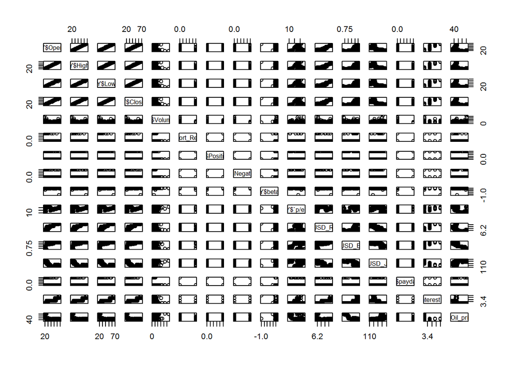

```r
pairs(Y$Open~Y$High+Y$Low+Y$Close+Y$Volume+Y$Report_Released+Y$Positive+Y$Negative+Y$beta+Y$`p/e`+X$USD_RMB+X$USD_EUR+X$USD_JYP+X$payday+X$`interest rate`+X$Oil_price)
```

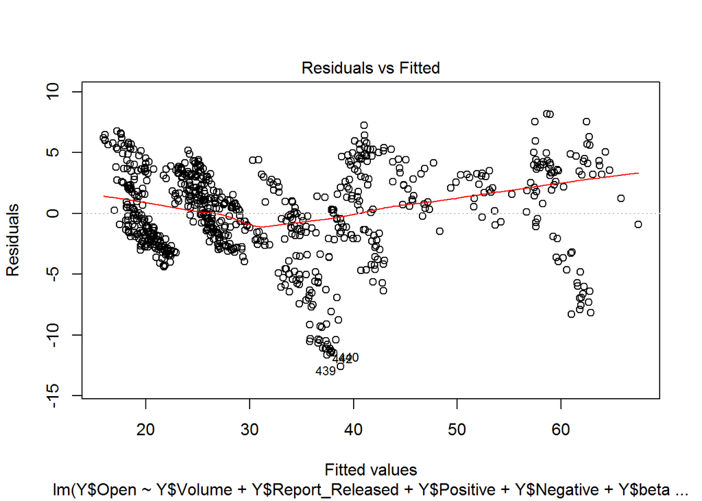

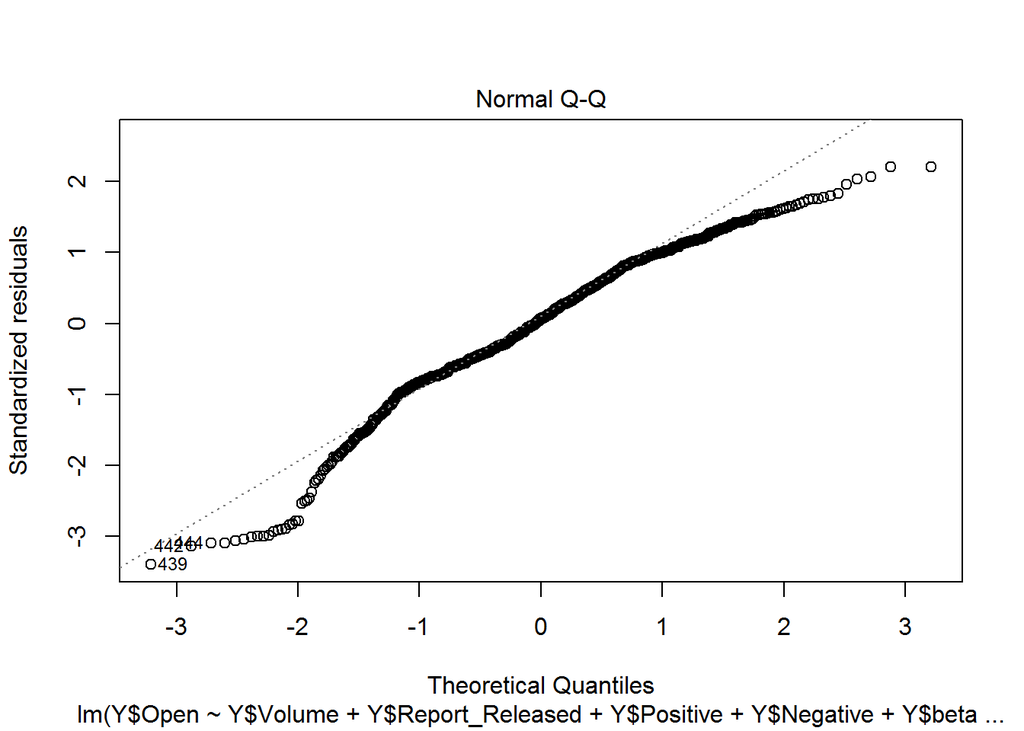

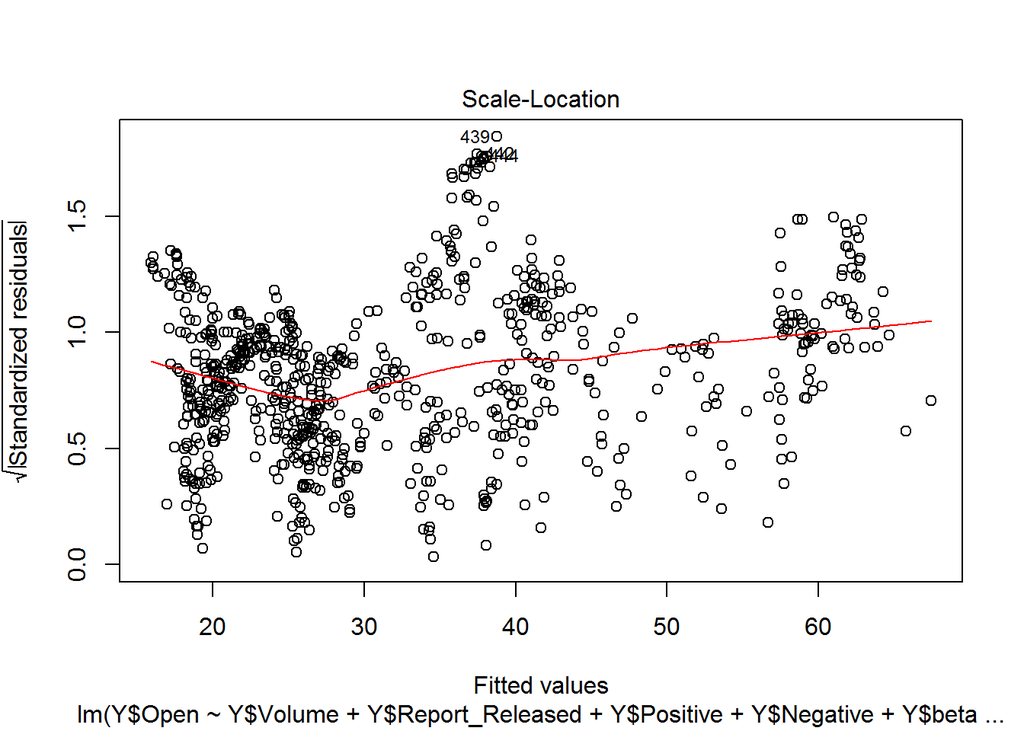

```r
plot(m2)
```

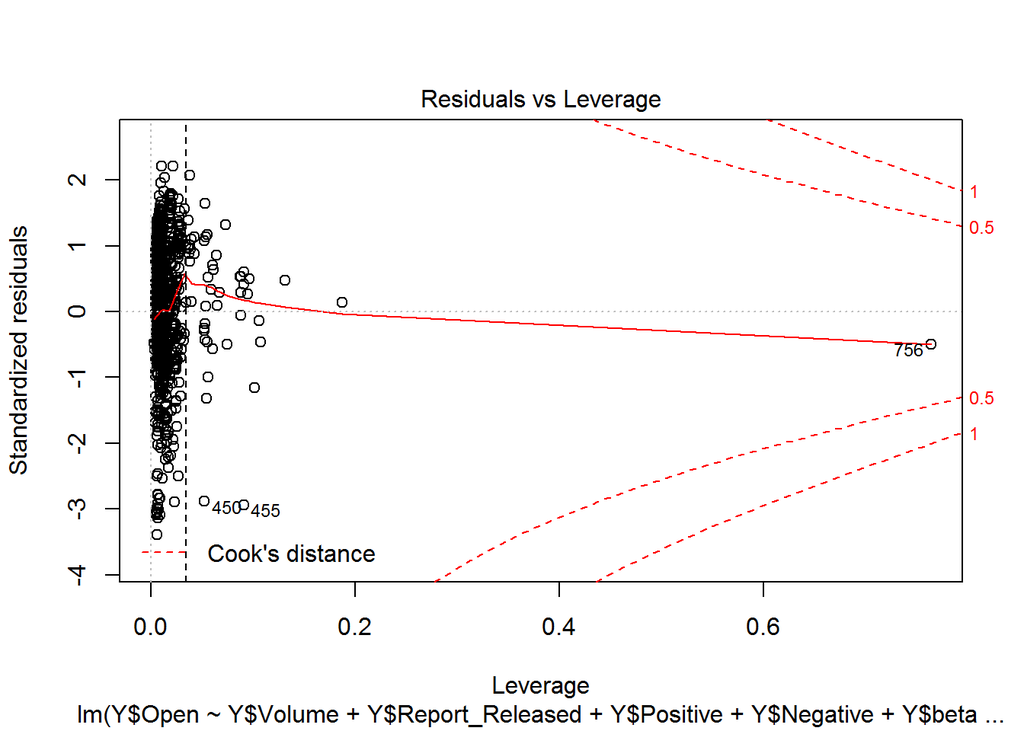

```r
abline(v=2*13/756,lty=2)
```

#Correlations between the predictors

```r
A <- cbind(Y$Volume,Y$Report_Released,Y$Positive,Y$Negative,Y$beta,Y$`p/e`,X$USD_RMB,X$USD_EUR,X$USD_JYP,X$payday,X$`interest rate`,X$Oil_price)
c <- cor(A)
round(c,3)
```

```
##         [,1]   [,2]   [,3]   [,4]   [,5]   [,6]   [,7]   [,8]   [,9]
##  [1,]  1.000  0.038  0.066 -0.029  0.018 -0.062 -0.074 -0.262  0.155
##  [2,]  0.038  1.000 -0.012  0.007 -0.032 -0.015 -0.016 -0.011  0.005
##  [3,]  0.066 -0.012  1.000 -0.098  0.002 -0.014  0.031 -0.018 -0.060
##  [4,] -0.029  0.007 -0.098  1.000  0.027 -0.047 -0.074 -0.059  0.062
##  [5,]  0.018 -0.032  0.002  0.027  1.000 -0.031 -0.043 -0.020  0.014
##  [6,] -0.062 -0.015 -0.014 -0.047 -0.031  1.000  0.167  0.496 -0.132
##  [7,] -0.074 -0.016  0.031 -0.074 -0.043  0.167  1.000  0.628 -0.840
##  [8,] -0.262 -0.011 -0.018 -0.059 -0.020  0.496  0.628  1.000 -0.616
##  [9,]  0.155  0.005 -0.060  0.062  0.014 -0.132 -0.840 -0.616  1.000
## [10,] -0.065 -0.021 -0.009 -0.015  0.015  0.001 -0.003 -0.019  0.006
## [11,] -0.006 -0.012  0.026 -0.050 -0.088  0.106  0.902  0.520 -0.738
## [12,]  0.245  0.002  0.015  0.092 -0.021 -0.507 -0.509 -0.888  0.526
##        [,10]  [,11]  [,12]
##  [1,] -0.065 -0.006  0.245
##  [2,] -0.021 -0.012  0.002
##  [3,] -0.009  0.026  0.015
##  [4,] -0.015 -0.050  0.092
##  [5,]  0.015 -0.088 -0.021
##  [6,]  0.001  0.106 -0.507
##  [7,] -0.003  0.902 -0.509
##  [8,] -0.019  0.520 -0.888
##  [9,]  0.006 -0.738  0.526
## [10,]  1.000 -0.021  0.017
## [11,] -0.021  1.000 -0.396
## [12,]  0.017 -0.396  1.000
```

## Plots of standardized residuals against each predictor and the fitted values

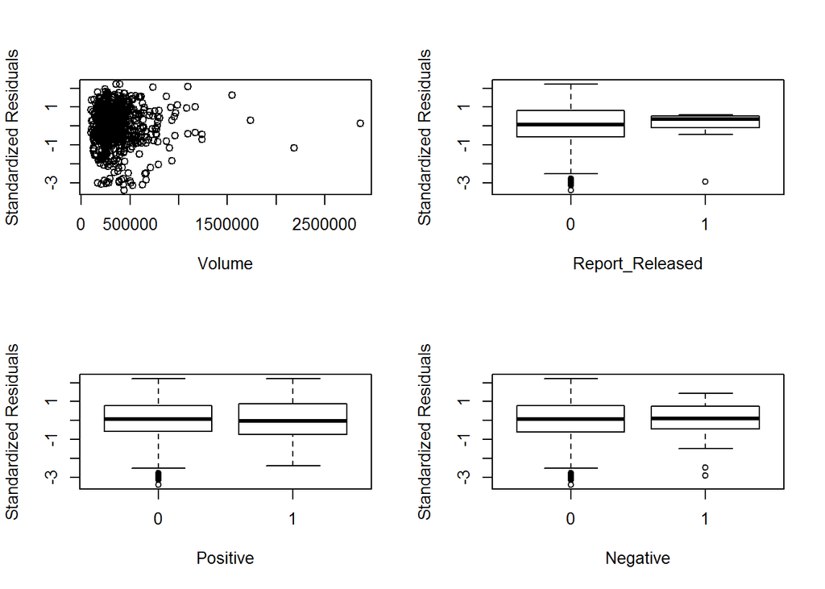

```r
StanRes1 <- rstandard(m2)
par(mfrow=c(2,2))
plot(Y$Volume,StanRes1, ylab="Standardized Residuals",xlab = "Volume")
boxplot(StanRes1~Y$Report_Released, ylab="Standardized Residuals",xlab = "Report_Released")
boxplot(StanRes1~Y$Positive, ylab="Standardized Residuals",xlab = "Positive")
boxplot(StanRes1~Y$Negative, ylab="Standardized Residuals",xlab ="Negative")
```

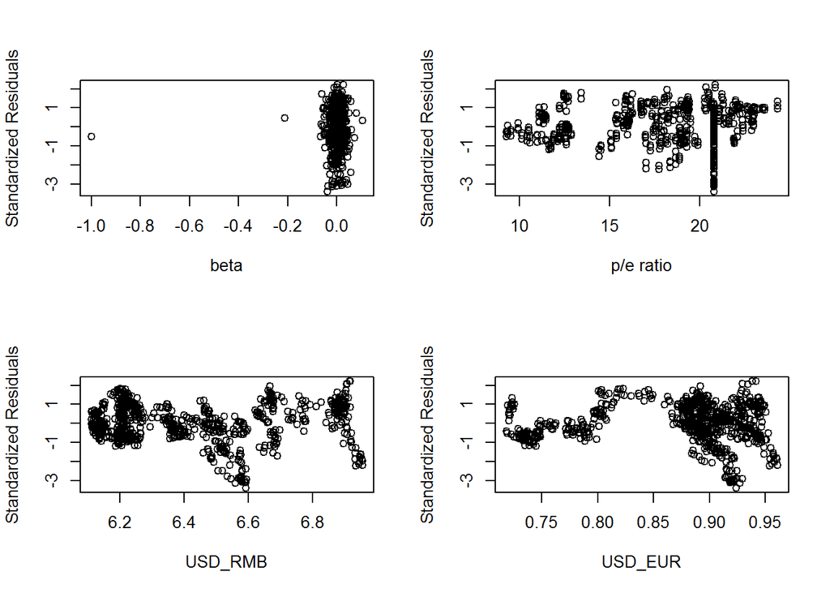

```r
plot(Y$beta,StanRes1, ylab="Standardized Residuals",xlab = "beta")
plot(Y$`p/e`,StanRes1, ylab="Standardized Residuals",xlab = "p/e ratio")
plot(X$USD_RMB,StanRes1, ylab="Standardized Residuals",xlab = "USD_RMB")
plot(X$USD_EUR,StanRes1, ylab="Standardized Residuals",xlab = "USD_EUR")
```

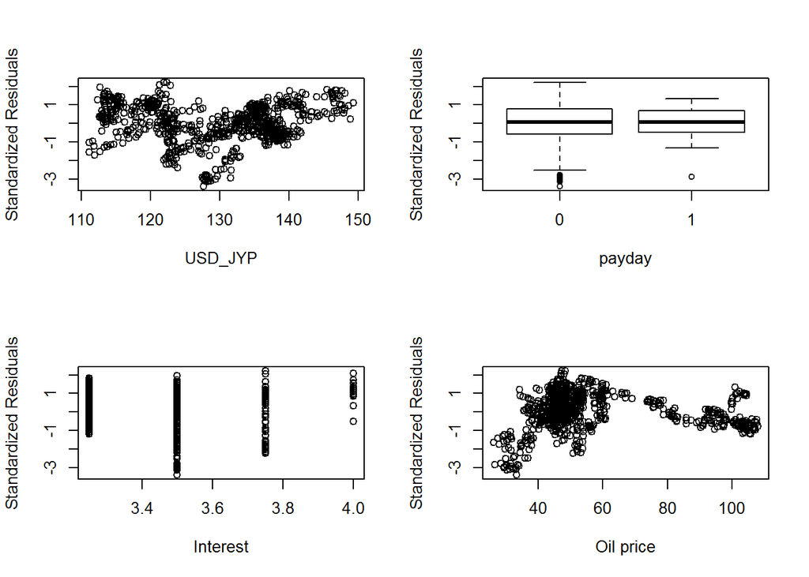

```r
plot(X$USD_JYP,StanRes1, ylab="Standardized Residuals",xlab = "USD_JYP")
boxplot(StanRes1~X$payday, ylab="Standardized Residuals",xlab ="payday")
plot(X$`interest rate`,StanRes1, ylab="Standardized Residuals",xlab = "Interest")
plot(X$Oil_price,StanRes1, ylab="Standardized Residuals",xlab = "Oil price")
```

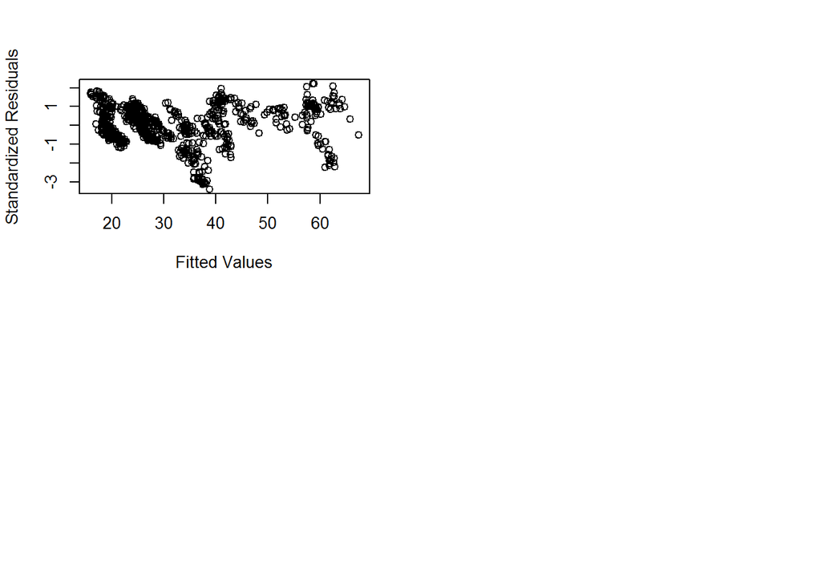

```r
plot(m2$fitted.values,StanRes1, ylab="Standardized Residuals",xlab="Fitted Values")
```

## Added-Variable Plot

```r
library(car)
```

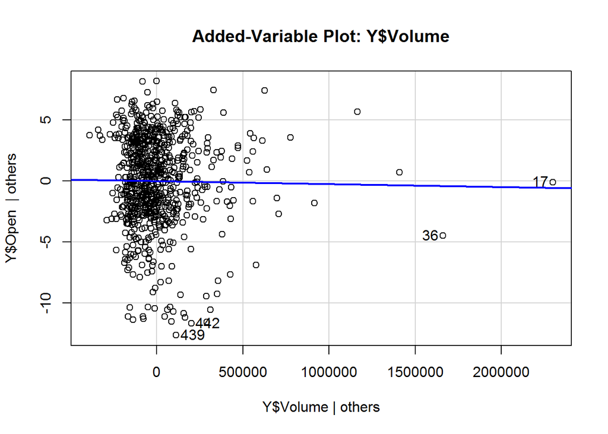

```r
avPlot(m2,variable=Y$Volume,ask=FALSE)
```

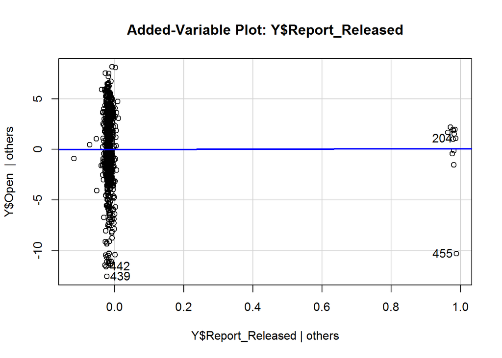

```r
avPlot(m2,variable=Y$Report_Released,ask=FALSE)
```

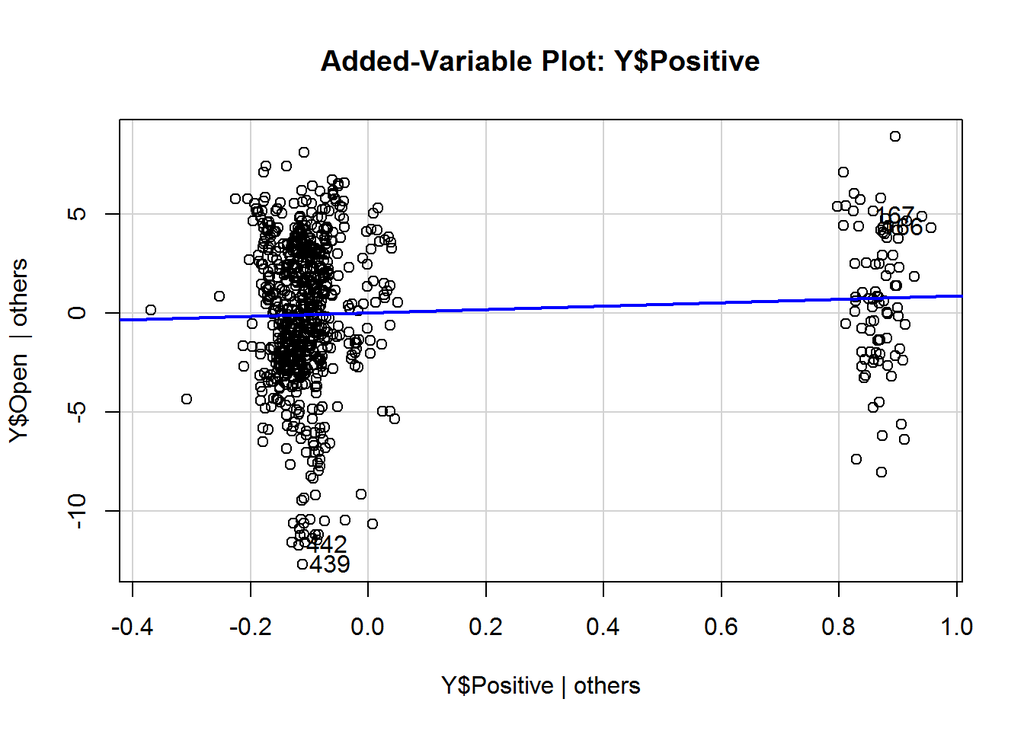

```r
avPlot(m2,variable=Y$Positive,ask=FALSE)
```

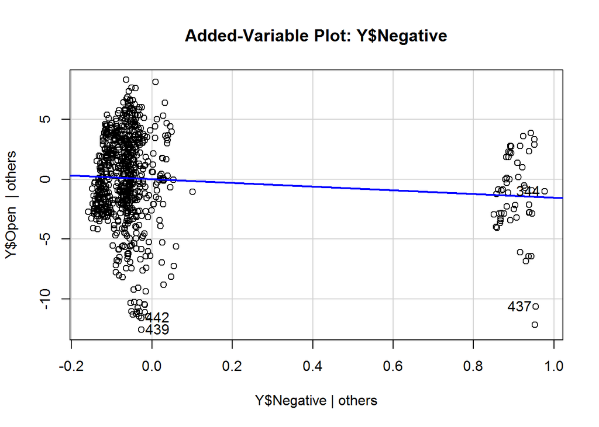

```r
avPlot(m2,variable=Y$Negative,ask=FALSE)
```

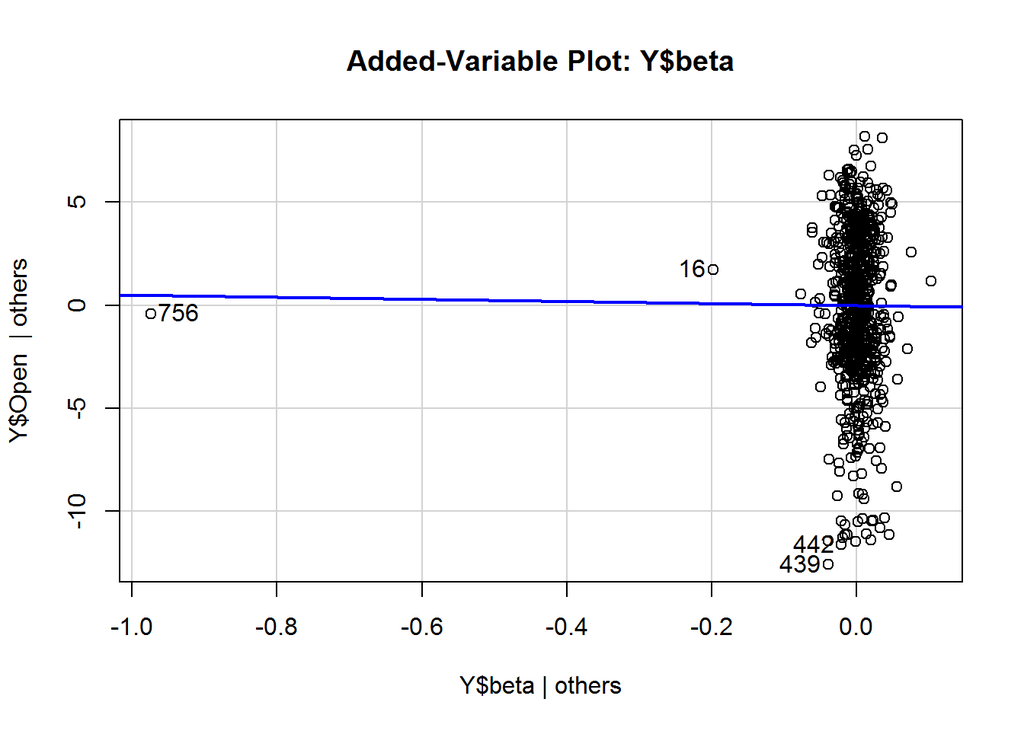

```r
avPlot(m2,variable=Y$beta,ask=FALSE)
```

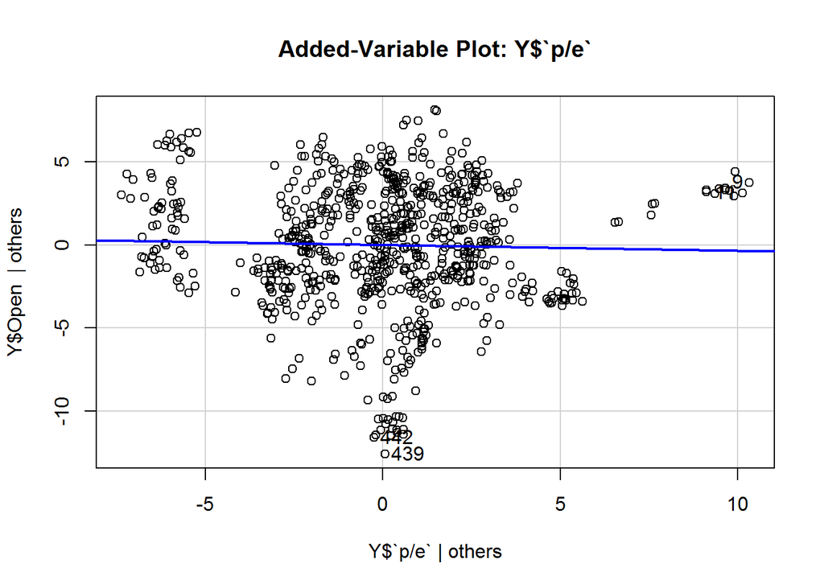

```r
avPlot(m2,variable=Y$`p/e`,ask=FALSE)
```

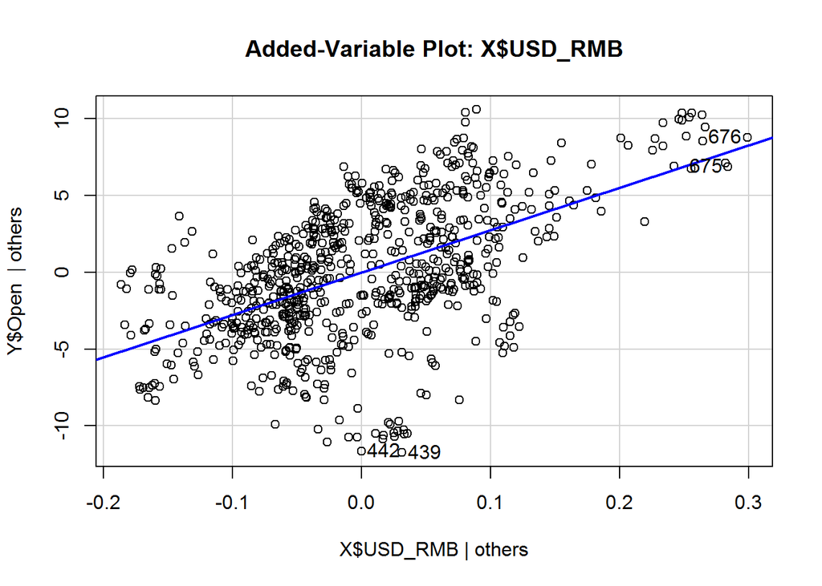

```r
avPlot(m2,variable=X$USD_RMB,ask=FALSE)
```

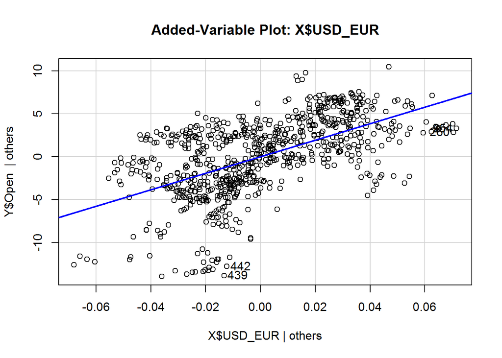

```r
avPlot(m2,variable=X$USD_EUR,ask=FALSE)
```

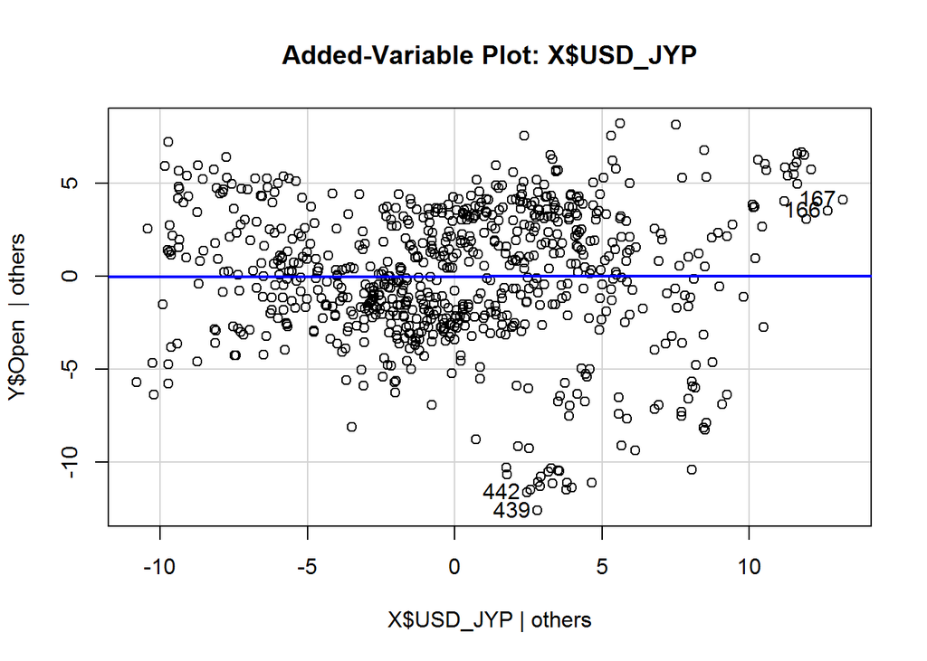

```r
avPlot(m2,variable=X$USD_JYP,ask=FALSE)
```

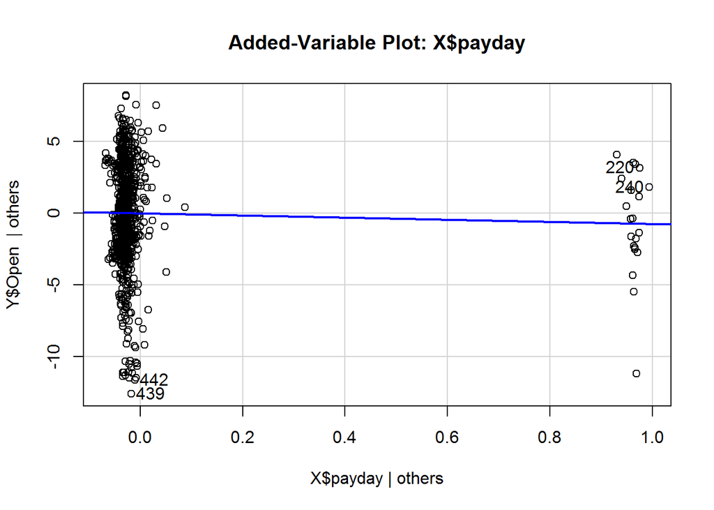

```r
avPlot(m2,variable=X$payday,ask=FALSE)
```

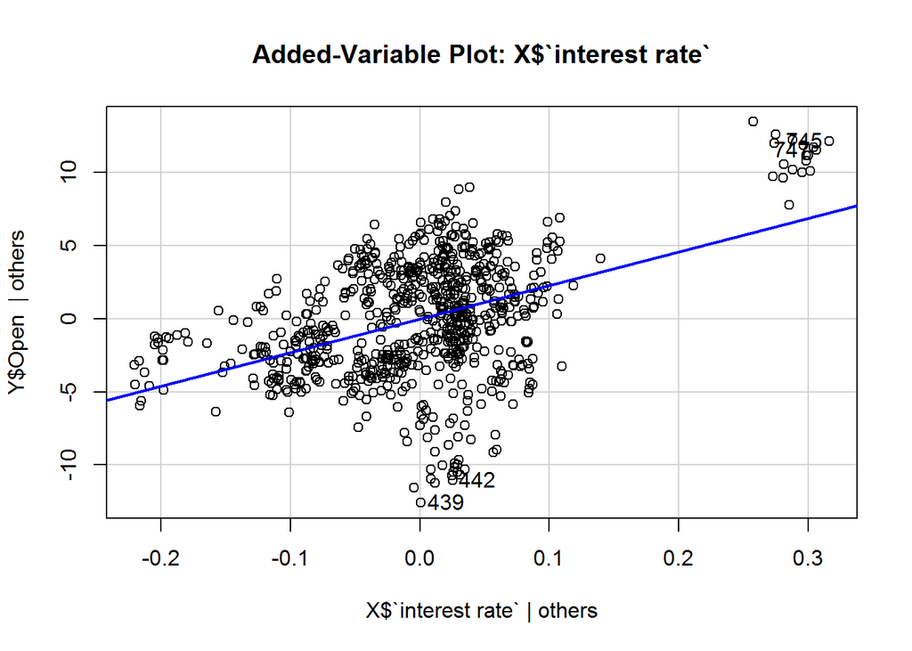

```r
avPlot(m2,variable=X$`interest rate`,ask=FALSE)
```

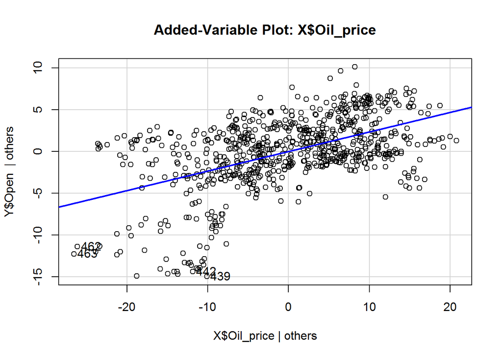

```r
avPlot(m2,variable=X$Oil_price,ask=FALSE)
```

## Inverse response plot

```r
library(alr3)
```

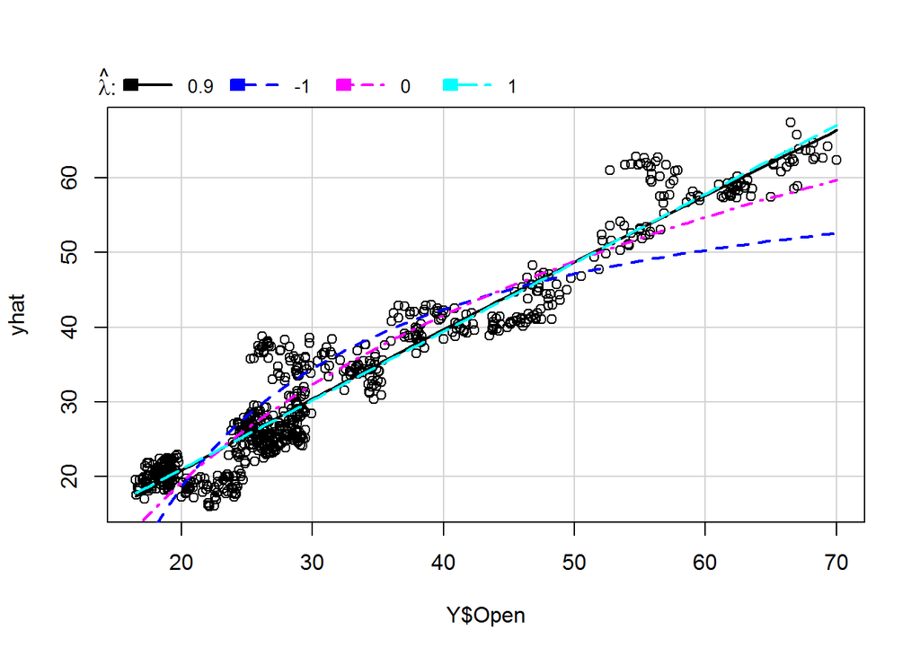

```
##       lambda       RSS
## 1  0.8987505  9478.158
## 2 -1.0000000 24442.277
## 3  0.0000000 12906.302
## 4  1.0000000  9518.401
```

```r
inverse.response.plot(m2,key=TRUE)
```

## Log-likelihood for the Box-Cox transformation method

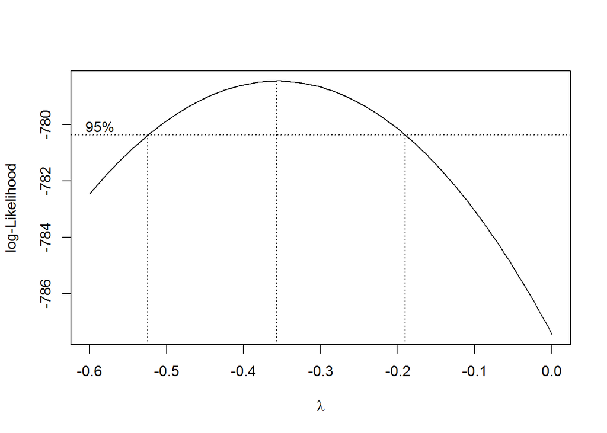

```r
library(MASS)
boxcox(m2,lambda=seq(-0.6,0,length=20))
```

```r
m3 <- update(m2, subset=(1:756)[-c(756)])
summary(m3)
```

```
##
## Call:
## lm(formula = Y$Open ~ Y$Volume + Y$Report_Released + Y$Positive +
##     Y$Negative + Y$beta + Y$`p/e` + X$USD_RMB + X$USD_EUR + X$USD_JYP +
##     X$payday + X$`interest rate` + X$Oil_price, subset = (1:756)[-c(756)])
##
## Residuals:
##     Min      1Q  Median      3Q     Max
## -12.726  -2.182   0.238   2.930   8.195
##
## Coefficients:
##                     Estimate Std. Error t value Pr(>|t|)
## (Intercept)       -3.200e+02  1.034e+01 -30.955   <2e-16 ***
## Y$Volume          -2.190e-07  6.675e-07  -0.328   0.7429
## Y$Report_Released  3.519e-02  1.089e+00   0.032   0.9742
## Y$Positive         8.450e-01  4.340e-01   1.947   0.0519 .
## Y$Negative        -1.538e+00  5.385e-01  -2.857   0.0044 **
## Y$beta            -3.394e+00  6.663e+00  -0.509   0.6106
## Y$`p/e`           -3.639e-02  4.657e-02  -0.781   0.4349
## X$USD_RMB          2.757e+01  1.595e+00  17.287   <2e-16 ***
## X$USD_EUR          9.632e+01  5.110e+00  18.850   <2e-16 ***
## X$USD_JYP          2.823e-03  2.792e-02   0.101   0.9195
## X$payday          -7.297e-01  8.285e-01  -0.881   0.3787
## X$`interest rate`  2.306e+01  1.734e+00  13.297   <2e-16 ***
## X$Oil_price        2.338e-01  1.429e-02  16.359   <2e-16 ***
## ---
## Signif. codes:  0 '***' 0.001 '**' 0.01 '*' 0.05 '.' 0.1 ' ' 1
##
## Residual standard error: 3.726 on 742 degrees of freedom
## Multiple R-squared:  0.923,  Adjusted R-squared:  0.9218
## F-statistic: 741.6 on 12 and 742 DF,  p-value: < 2.2e-16
```

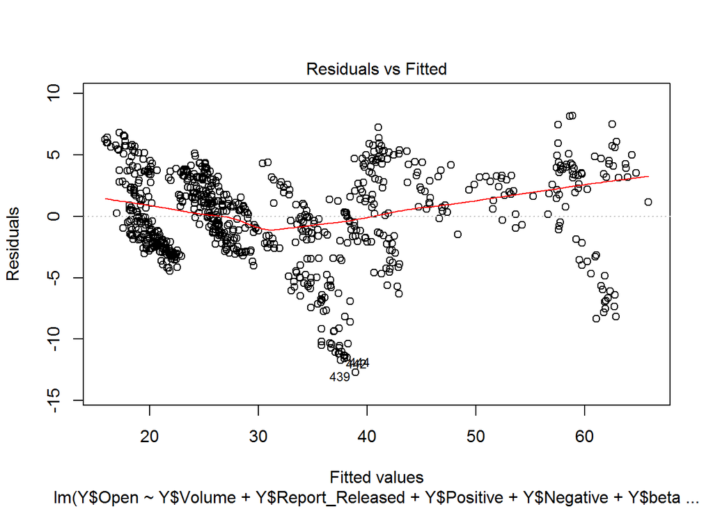

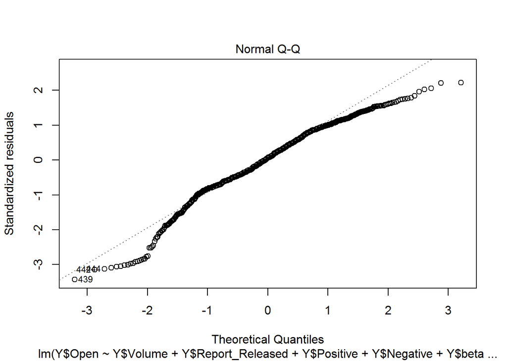

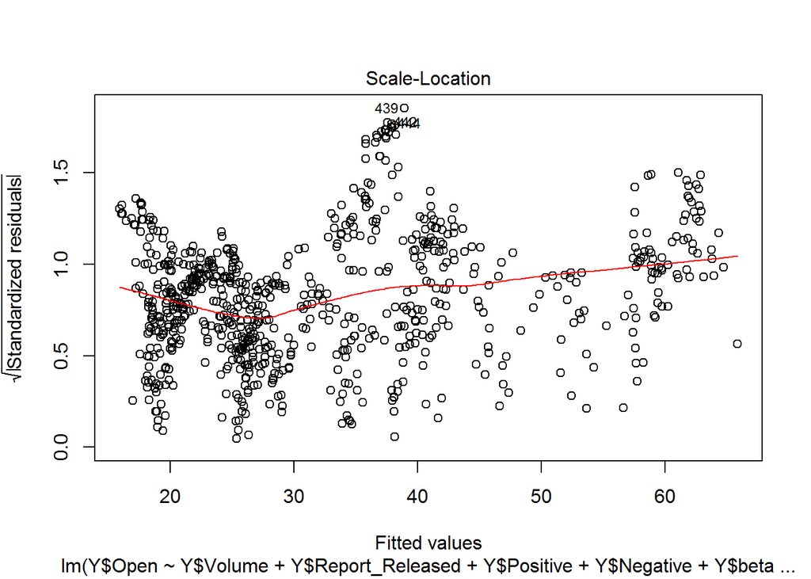

```r
plot(m3)
```

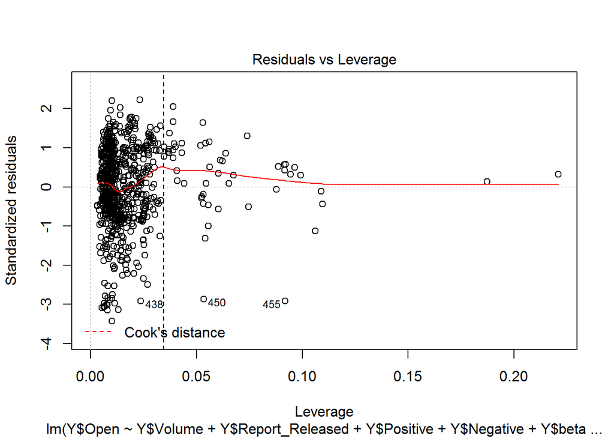

```r
abline(v=2*13/755,lty=2)
```

## Model selection

Conduct F- test to see if the coefficient is 0.

```r
anova(m2)  ## conduct F- test to see if the coefficient is 0
```

```
## Analysis of Variance Table
##
## Response: Y$Open
##                    Df Sum Sq Mean Sq   F value    Pr(>F)
## Y$Volume            1    774     774   55.8005 2.256e-13 ***
## Y$Report_Released   1     25      25    1.7777   0.18284
## Y$Positive          1    325     325   23.4420 1.567e-06 ***
## Y$Negative          1    817     817   58.9191 5.176e-14 ***
## Y$beta              1    610     610   43.9737 6.404e-11 ***
## Y$`p/e`             1   3219    3219  232.0807 < 2.2e-16 ***
## X$USD_RMB           1 111107  111107 8010.9510 < 2.2e-16 ***
## X$USD_EUR           1   1094    1094   78.8721 < 2.2e-16 ***
## X$USD_JYP           1     59      59    4.2179   0.04035 *
## X$payday            1     22      22    1.6074   0.20526
## X$`interest rate`   1   2927    2927  211.0323 < 2.2e-16 ***
## X$Oil_price         1   3724    3724  268.5263 < 2.2e-16 ***
## Residuals         743  10305      14
## ---
## Signif. codes:  0 '***' 0.001 '**' 0.01 '*' 0.05 '.' 0.1 ' ' 1
```

```r
summary(powerTransform(m2))
```

```
## bcPower Transformation to Normality
##    Est Power Rounded Pwr Wald Lwr Bnd Wald Upr Bnd
## Y1   -0.3559        -0.5      -0.5228       -0.189
##
## Likelihood ratio test that transformation parameter is equal to 0
##  (log transformation)
##                            LRT df       pval
## LR test, lambda = (0) 18.00915  1 2.1985e-05
##
## Likelihood ratio test that no transformation is needed
##                            LRT df       pval
## LR test, lambda = (1) 274.7002  1 < 2.22e-16
```

```r
Z=merge(X, Y, sort = FALSE)
attach(Z)
```

Use leaps to determine which variable we should have.

```r
#A <- cbind(Y$Volume,Y$Report_Released,Y$Positive,Y$Negative,Y$beta,Y$`p/e`,X$USD_RMB,X$USD_EUR,X$USD_JYP,X$payday,X$`interest rate`,X$Oil_price)
B = cbind(Volume,Report_Released,Positive, Negative, beta, Z$`p/e` ,USD_EUR,USD_JYP, USD_RMB, payday,Z$`interest rate`, Oil_price)

library(leaps)
```

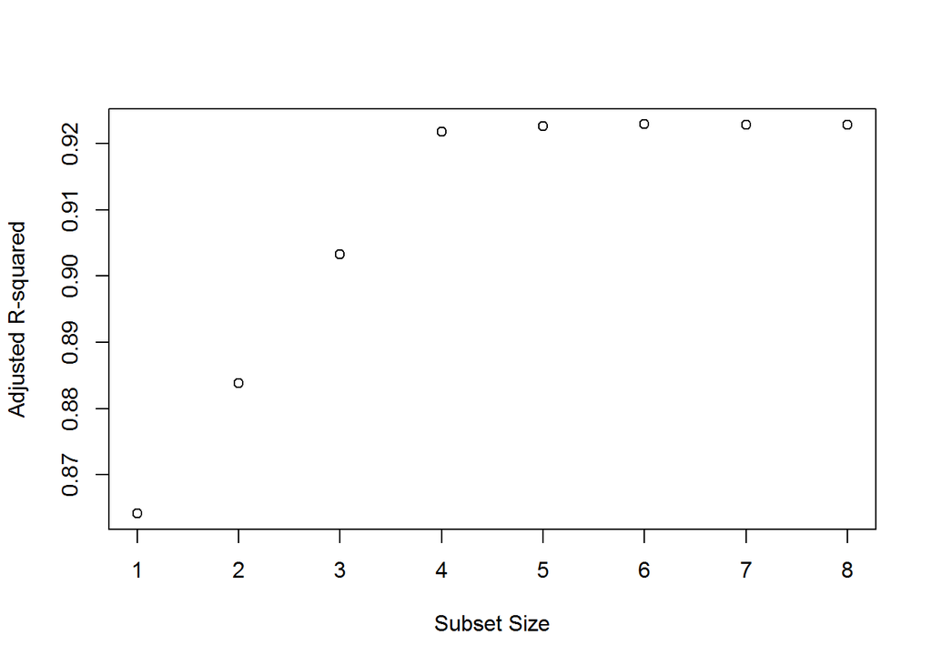

```r
b = regsubsets(as.matrix(B),Open)
rs <- summary(b)
par(mfrow=c(1,1))
plot(1:8,rs$adjr2,xlab="Subset Size",ylab="Adjusted R-squared")
```

```r
#subsets(b,statistic=c("adjr2"))
```

Using AIC, BIC, AICC to choose reduced model.

```r
om1 <- lm(Y$Open~X$Oil_price)
om2 <- lm(Y$Open~X$Oil_price+X$`interest rate`)
om3 <- lm(Y$Open~X$Oil_price+X$`interest rate`+X$USD_RMB)
om4 <- lm(Y$Open~X$Oil_price+X$`interest rate`+X$USD_RMB+X$USD_EUR)
om5 <- lm(Y$Open~X$Oil_price+X$`interest rate`+X$USD_EUR+Y$Negative)
om6 <- lm(Y$Open~X$Oil_price+X$`interest rate`+X$USD_EUR+Y$Negative +Y$Positive)
#Y$Open~Y$Volume+Y$Report_Released+Y$Positive+Y$Negative+Y$beta+Y$`p/e`+X$USD_RMB+X$USD_EUR+X$USD_JYP+X$payday+X$`interest rate`+X$Oil_price
#Calculate AIC
extractAIC(om1,k=2)
```

```
## [1]    2.000 3754.793
```

```r
extractAIC(om2,k=2)
```

```
## [1]    3.000 2635.559
```

```r
extractAIC(om3,k=2)
```

```
## [1]    4.000 2298.364
```

```r
extractAIC(om4,k=2)
```

```
## [1]    5.000 1999.661
```

```r
extractAIC(om5,k=2)
```

```
## [1]    5.000 2320.536
```

```r
extractAIC(om6,k=2)
```

```
## [1]    6.000 2318.177
```

```r
#Calculate AICc
n <- length(om1$residuals)
npar <- length(om1$coefficients) +1
extractAIC(om1,k=2)+2*npar*(npar+1)/(n-npar-1)
```

```
## [1]    2.031915 3754.825020
```

```r
npar <- length(om2$coefficients) +1
extractAIC(om2,k=2)+2*npar*(npar+1)/(n-npar-1)
```

```
## [1]    3.053262 2635.611852
```

```r
npar <- length(om3$coefficients) +1
extractAIC(om3,k=2)+2*npar*(npar+1)/(n-npar-1)
```

```
## [1]    4.080 2298.444
```

```r
npar <- length(om4$coefficients) +1
extractAIC(om4,k=2)+2*npar*(npar+1)/(n-npar-1)
```

```
## [1]    5.11215 1999.77355
```

```r
npar <- length(om5$coefficients) +1
extractAIC(om5,k=2)+2*npar*(npar+1)/(n-npar-1)
```

```
## [1]    5.11215 2320.64848
```

```r
npar <- length(om6$coefficients) +1
extractAIC(om6,k=2)+2*npar*(npar+1)/(n-npar-1)
```

```
## [1]    6.149733 2318.327122
```

```r
#Calculate BIC
extractAIC(om1,k=log(n))
```

```
## [1]    2.000 3764.049
```

```r
extractAIC(om2,k=log(n))
```

```
## [1]    3.000 2649.443
```

```r
extractAIC(om3,k=log(n))
```

```
## [1]    4.000 2316.876
```

```r
extractAIC(om4,k=log(n))
```

```
## [1]    5.000 2022.802
```

```r
extractAIC(om5,k=log(n))
```

```
## [1]    5.000 2343.677
```

```r
extractAIC(om6,k=log(n))
```

```
## [1]    6.000 2345.946
```

**base on AIC, AICC and BIC, we will choose model 4,which contains Oil_price,interest.rate,USD_RMB,USD_EUR**

use backward selection based on AIC

```r
om7 = m2
backAIC <- step(om7,direction="backward")
```

```
## Start:  AIC=2000.93
## Y$Open ~ Y$Volume + Y$Report_Released + Y$Positive + Y$Negative +
##     Y$beta + Y$`p/e` + X$USD_RMB + X$USD_EUR + X$USD_JYP + X$payday +
##     X$`interest rate` + X$Oil_price
##
##                     Df Sum of Sq   RSS    AIC
## - Y$Report_Released  1       0.1 10305 1998.9
## - X$USD_JYP          1       0.2 10305 1998.9
## - Y$beta             1       0.3 10305 1999.0
## - Y$Volume           1       1.7 10307 1999.1
## - Y$`p/e`            1       7.6 10313 1999.5
## - X$payday           1      11.0 10316 1999.7
## <none>                           10305 2000.9
## - Y$Positive         1      53.3 10358 2002.8
## - Y$Negative         1     114.6 10420 2007.3
## - X$`interest rate`  1    2452.4 12757 2160.3
## - X$Oil_price        1    3724.3 14029 2232.2
## - X$USD_RMB          1    4167.9 14473 2255.7
## - X$USD_EUR          1    4929.5 15234 2294.5
##
## Step:  AIC=1998.93
## Y$Open ~ Y$Volume + Y$Positive + Y$Negative + Y$beta + Y$`p/e` +
##     X$USD_RMB + X$USD_EUR + X$USD_JYP + X$payday + X$`interest rate` +
##     X$Oil_price
##
##                     Df Sum of Sq   RSS    AIC
## - X$USD_JYP          1       0.2 10305 1997.0
## - Y$beta             1       0.3 10305 1997.0
## - Y$Volume           1       1.7 10307 1997.1
## - Y$`p/e`            1       7.6 10313 1997.5
## - X$payday           1      11.1 10316 1997.8
## <none>                           10305 1998.9
## - Y$Positive         1      53.3 10358 2000.8
## - Y$Negative         1     114.6 10420 2005.3
## - X$`interest rate`  1    2452.4 12758 2158.3
## - X$Oil_price        1    3725.3 14030 2230.2
## - X$USD_RMB          1    4168.5 14474 2253.7
## - X$USD_EUR          1    4929.5 15235 2292.5
##
## Step:  AIC=1996.95
```

[output cut: 58 more lines]

```
## - X$USD_EUR          1    5241.6 15557 2300.3
## - X$USD_RMB          1    5655.7 15971 2320.2
##
## Step:  AIC=1990.49
## Y$Open ~ Y$Positive + Y$Negative + X$USD_RMB + X$USD_EUR + X$`interest rate` +
##     X$Oil_price
##
##                     Df Sum of Sq   RSS    AIC
## <none>                           10326 1990.5
## - Y$Positive         1      52.7 10379 1992.3
## - Y$Negative         1     112.3 10439 1996.7
## - X$`interest rate`  1    2540.7 12867 2154.8
## - X$Oil_price        1    3899.2 14226 2230.7
## - X$USD_EUR          1    5248.1 15574 2299.2
## - X$USD_RMB          1    5644.9 15971 2318.2
```

```r
###########use backward selection based on BIC
backBIC <- step(om7,direction="backward",k = log(n))
```

```
## Start:  AIC=2061.09
## Y$Open ~ Y$Volume + Y$Report_Released + Y$Positive + Y$Negative +
##     Y$beta + Y$`p/e` + X$USD_RMB + X$USD_EUR + X$USD_JYP + X$payday +
##     X$`interest rate` + X$Oil_price
##
##                     Df Sum of Sq   RSS    AIC
## - Y$Report_Released  1       0.1 10305 2054.5
## - X$USD_JYP          1       0.2 10305 2054.5
## - Y$beta             1       0.3 10305 2054.5
## - Y$Volume           1       1.7 10307 2054.6
## - Y$`p/e`            1       7.6 10313 2055.0
## - X$payday           1      11.0 10316 2055.3
## - Y$Positive         1      53.3 10358 2058.4
## <none>                           10305 2061.1
## - Y$Negative         1     114.6 10420 2062.8
## - X$`interest rate`  1    2452.4 12757 2215.9
## - X$Oil_price        1    3724.3 14029 2287.7
## - X$USD_RMB          1    4167.9 14473 2311.2
## - X$USD_EUR          1    4929.5 15234 2350.0
##
## Step:  AIC=2054.47
## Y$Open ~ Y$Volume + Y$Positive + Y$Negative + Y$beta + Y$`p/e` +
##     X$USD_RMB + X$USD_EUR + X$USD_JYP + X$payday + X$`interest rate` +
##     X$Oil_price
##
##                     Df Sum of Sq   RSS    AIC
## - X$USD_JYP          1       0.2 10305 2047.8
## - Y$beta             1       0.3 10305 2047.9
## - Y$Volume           1       1.7 10307 2048.0
## - Y$`p/e`            1       7.6 10313 2048.4
## - X$payday           1      11.1 10316 2048.7
## - Y$Positive         1      53.3 10358 2051.7
## <none>                           10305 2054.5
## - Y$Negative         1     114.6 10420 2056.2
## - X$`interest rate`  1    2452.4 12758 2209.2
## - X$Oil_price        1    3725.3 14030 2281.1
## - X$USD_RMB          1    4168.5 14474 2304.7
## - X$USD_EUR          1    4929.5 15235 2343.4
##
## Step:  AIC=2047.85
```

[output cut: 70 more lines]

```
## - X$Oil_price        1    3899.2 14226 2258.4
## - X$USD_EUR          1    5248.1 15574 2326.9
## - X$USD_RMB          1    5644.9 15971 2345.9
##
## Step:  AIC=2020.11
## Y$Open ~ Y$Negative + X$USD_RMB + X$USD_EUR + X$`interest rate` +
##     X$Oil_price
##
##                     Df Sum of Sq   RSS    AIC
## <none>                           10379 2020.1
## - Y$Negative         1     128.7 10508 2022.8
## - X$`interest rate`  1    2535.7 12915 2178.7
## - X$Oil_price        1    3898.1 14277 2254.6
## - X$USD_EUR          1    5222.7 15602 2321.6
## - X$USD_RMB          1    5684.5 16064 2343.7
```

```r
###########Forward selection based on AIC
mint <- lm(Open~1,data=Z)
x1 = Volume
x2 = Report_Released
x3 =Positive
x4 = Negative
x5 = beta
x6 = Z$`p/e`
x7 = JYP_USD
x8 = USD_RMB
x9 = USD_EUR
x10 = USD_JYP
x11 = payday
x12 = Z$`interest rate`
x13 =Oil_price

forwardAIC <- step(mint,scope=list(lower=~1,
  upper=~x1+x2+x3+x4+x5+x6+x7+x8+x9+x10+x11+x12+x13),
  direction="forward", data=Z)
```

```
## Start:  AIC=3921.89
## Open ~ 1
##
##        Df Sum of Sq    RSS    AIC
## + x8    1    116694  18314 2413.7
## + x12   1    109174  25834 2673.7
## + x10   1     82256  52752 3213.5
## + x7    1     82199  52809 3214.3
## + x9    1     56240  78768 3516.5
## + x13   1     27059 107948 3754.8
## + x6    1      3631 131376 3903.3
## + x4    1       865 134142 3919.0
## + x1    1       774 134234 3919.5
## + x5    1       665 134343 3920.2
## <none>              135008 3921.9
## + x3    1       263 134744 3922.4
## + x11   1        54 134954 3923.6
## + x2    1        36 134971 3923.7
##
## Step:  AIC=2413.66
## Open ~ x8
##
##        Df Sum of Sq   RSS    AIC
## + x12   1   2668.94 15645 2296.6
## + x9    1    841.09 17473 2380.1
## + x5    1    124.10 18190 2410.5
## + x13   1    116.75 18197 2410.8
## <none>              18314 2413.7
## + x11   1     38.71 18275 2414.1
## + x3    1     32.26 18282 2414.3
## + x4    1     15.90 18298 2415.0
## + x6    1      9.86 18304 2415.2
## + x1    1      6.63 18307 2415.4
## + x7    1      2.45 18312 2415.6
## + x2    1      0.23 18314 2415.7
## + x10   1      0.00 18314 2415.7
##
## Step:  AIC=2296.58
## Open ~ x8 + x12
##
```

[output cut: 89 more lines]

```
## <none>              7833.5 1785.6
## + x1    1     14.01 7819.5 1786.3
## + x11   1      6.14 7827.4 1787.0
## + x2    1      1.01 7832.5 1787.5
## + x5    1      1.00 7832.5 1787.5
##
## Step:  AIC=1747.49
## Open ~ x8 + x12 + x9 + x13 + x4 + x3 + x7 + x10 + x6
##
##        Df Sum of Sq    RSS    AIC
## <none>              7428.5 1747.5
## + x11   1    6.7947 7421.7 1748.8
## + x1    1    6.2287 7422.2 1748.8
## + x5    1    5.1868 7423.3 1749.0
## + x2    1    2.0683 7426.4 1749.3
```

```r
###Forward selection based on BIC
forwardBIC <- step(mint,scope=list(lower=~1,
  upper=~x1+x2+x3+x4+x5+x6+x7+x8+x9+x10+x11+x12+x13),
  direction="forward", data=Z,k=log(n))
```

```
## Start:  AIC=3926.52
## Open ~ 1
##
##        Df Sum of Sq    RSS    AIC
## + x8    1    116694  18314 2422.9
## + x12   1    109174  25834 2683.0
## + x10   1     82256  52752 3222.7
## + x7    1     82199  52809 3223.5
## + x9    1     56240  78768 3525.8
## + x13   1     27059 107948 3764.0
## + x6    1      3631 131376 3912.5
## <none>              135008 3926.5
## + x4    1       865 134142 3928.3
## + x1    1       774 134234 3928.8
## + x5    1       665 134343 3929.4
## + x3    1       263 134744 3931.7
## + x11   1        54 134954 3932.8
## + x2    1        36 134971 3932.9
##
## Step:  AIC=2422.92
## Open ~ x8
##
##        Df Sum of Sq   RSS    AIC
## + x12   1   2668.94 15645 2310.5
## + x9    1    841.09 17473 2394.0
## <none>              18314 2422.9
## + x5    1    124.10 18190 2424.4
## + x13   1    116.75 18197 2424.7
## + x11   1     38.71 18275 2427.9
## + x3    1     32.26 18282 2428.2
## + x4    1     15.90 18298 2428.9
## + x6    1      9.86 18304 2429.1
## + x1    1      6.63 18307 2429.3
## + x7    1      2.45 18312 2429.4
## + x2    1      0.23 18314 2429.5
## + x10   1      0.00 18314 2429.6
##
## Step:  AIC=2310.47
## Open ~ x8 + x12
##
```

[output cut: 43 more lines]

```
## + x2    1     0.031 10508 2029.4
##
## Step:  AIC=2020.11
## Open ~ x8 + x12 + x9 + x13 + x4
##
##        Df Sum of Sq   RSS    AIC
## <none>              10379 2020.1
## + x3    1    52.727 10326 2022.9
## + x7    1    40.757 10338 2023.8
## + x11   1    11.375 10368 2025.9
## + x6    1     8.398 10371 2026.1
## + x1    1     0.983 10378 2026.7
## + x10   1     0.549 10378 2026.7
## + x5    1     0.258 10379 2026.7
## + x2    1     0.063 10379 2026.7
```

```r
#### the model choose the x8 + x12 + x9 + x13 + x4
```

# Based on the above method, we finally choose a 6 variable model with independent variables:Positive, Negative, Oil price, Interest rate, USD_RMB, USD_EUR

```r
m5=lm(Y$Open~Y$Positive+Y$Negative+X$USD_RMB+X$USD_EUR+X$`interest rate`+X$Oil_price)

summary(m5)
```

```
##
## Call:
## lm(formula = Y$Open ~ Y$Positive + Y$Negative + X$USD_RMB + X$USD_EUR +
##     X$`interest rate` + X$Oil_price)
##
## Residuals:
##      Min       1Q   Median       3Q      Max
## -12.6121  -2.1253   0.2159   2.9166   8.1324
##
## Coefficients:
##                     Estimate Std. Error t value Pr(>|t|)
## (Intercept)       -319.98920    5.47315 -58.465  < 2e-16 ***
## Y$Positive           0.84134    0.43021   1.956  0.05088 .
## Y$Negative          -1.52842    0.53548  -2.854  0.00443 **
## X$USD_RMB           27.53832    1.36095  20.235  < 2e-16 ***
## X$USD_EUR           95.83628    4.91205  19.510  < 2e-16 ***
## X$`interest rate`   23.08245    1.70034  13.575  < 2e-16 ***
## X$Oil_price          0.23555    0.01401  16.817  < 2e-16 ***
## ---
## Signif. codes:  0 '***' 0.001 '**' 0.01 '*' 0.05 '.' 0.1 ' ' 1
##
## Residual standard error: 3.713 on 749 degrees of freedom
## Multiple R-squared:  0.9235, Adjusted R-squared:  0.9229
## F-statistic:  1507 on 6 and 749 DF,  p-value: < 2.2e-16
```

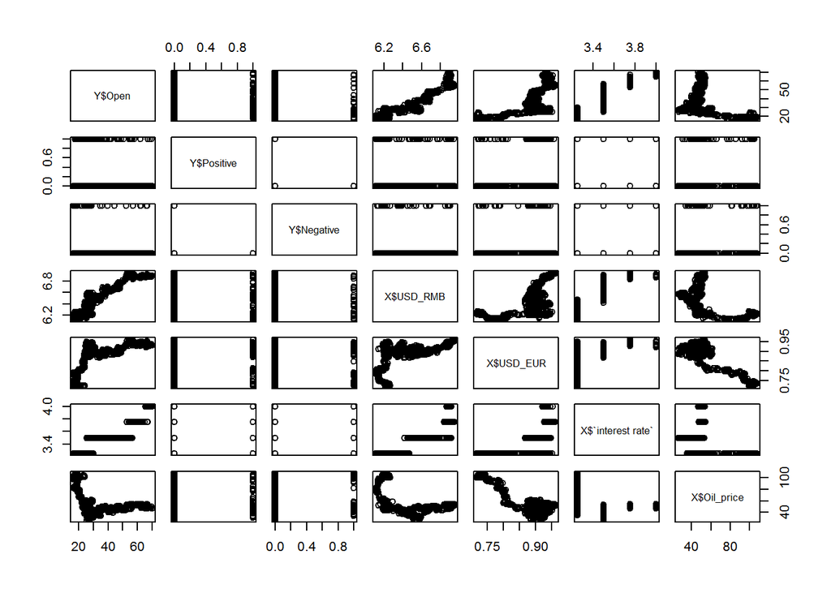

```r
pairs(Y$Open~Y$Positive+Y$Negative+X$USD_RMB+X$USD_EUR+X$`interest rate`+X$Oil_price)
```

```r
C <- cbind(Y$Positive,Y$Negative,X$USD_RMB,X$USD_EUR,X$`interest rate`,X$Oil_price)
c <- cor(C)
round(c,3)
```

```
##        [,1]   [,2]   [,3]   [,4]   [,5]   [,6]
## [1,]  1.000 -0.098  0.031 -0.018  0.026  0.015
## [2,] -0.098  1.000 -0.074 -0.059 -0.050  0.092
## [3,]  0.031 -0.074  1.000  0.628  0.902 -0.509
## [4,] -0.018 -0.059  0.628  1.000  0.520 -0.888
## [5,]  0.026 -0.050  0.902  0.520  1.000 -0.396
## [6,]  0.015  0.092 -0.509 -0.888 -0.396  1.000
```

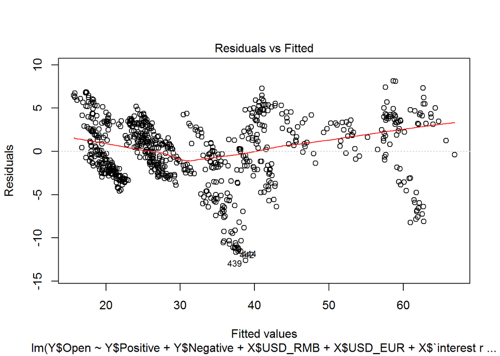

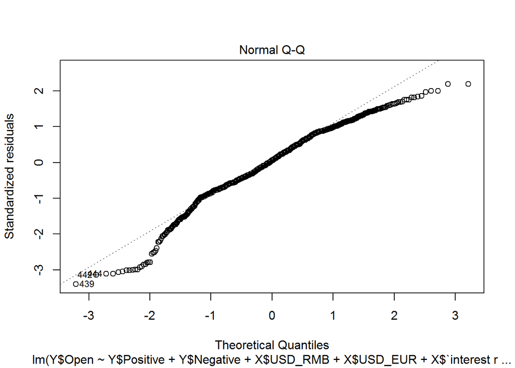

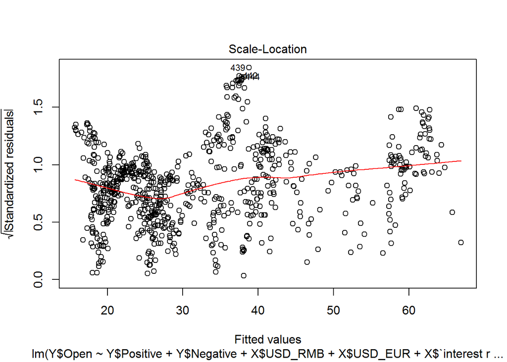

```r
plot(m5)
```

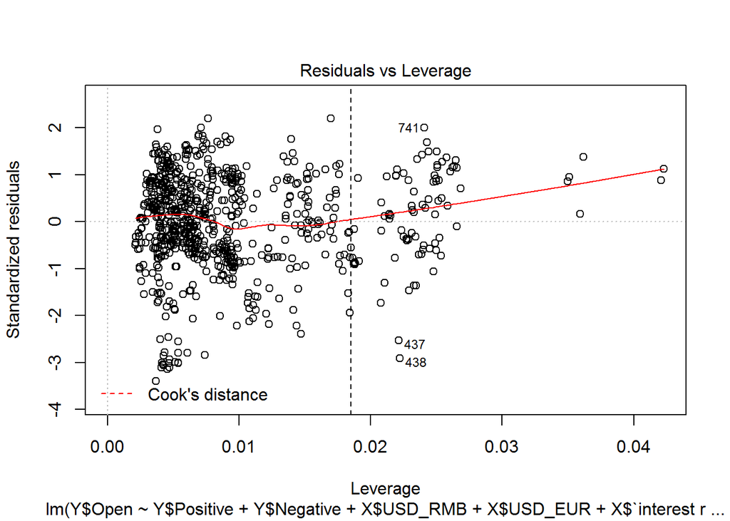

```r
abline(v=2*7/756,lty=2)
```

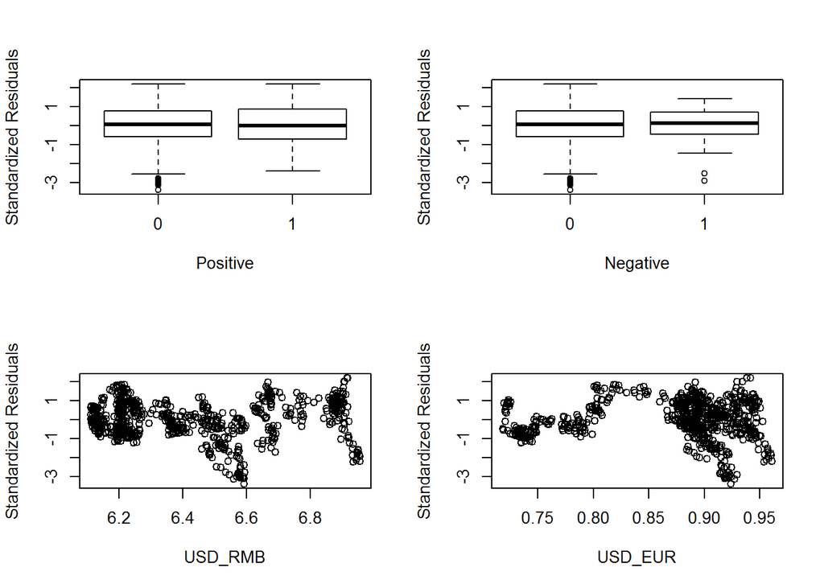

```r
StanRes2 <- rstandard(m5)
par(mfrow=c(2,2))

boxplot(StanRes2~Y$Positive, ylab="Standardized Residuals",xlab = "Positive")
boxplot(StanRes2~Y$Negative, ylab="Standardized Residuals",xlab ="Negative")
plot(X$USD_RMB,StanRes2, ylab="Standardized Residuals",xlab = "USD_RMB")
plot(X$USD_EUR,StanRes2, ylab="Standardized Residuals",xlab = "USD_EUR")
```

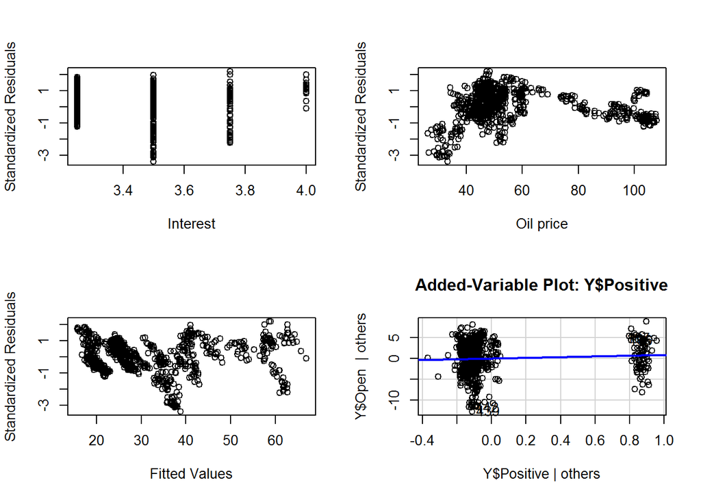

```r
plot(X$`interest rate`,StanRes2, ylab="Standardized Residuals",xlab = "Interest")
plot(X$Oil_price,StanRes2, ylab="Standardized Residuals",xlab = "Oil price")
plot(m5$fitted.values,StanRes2, ylab="Standardized Residuals",xlab="Fitted Values")


avPlot(m2,variable=Y$Positive,ask=FALSE)
```

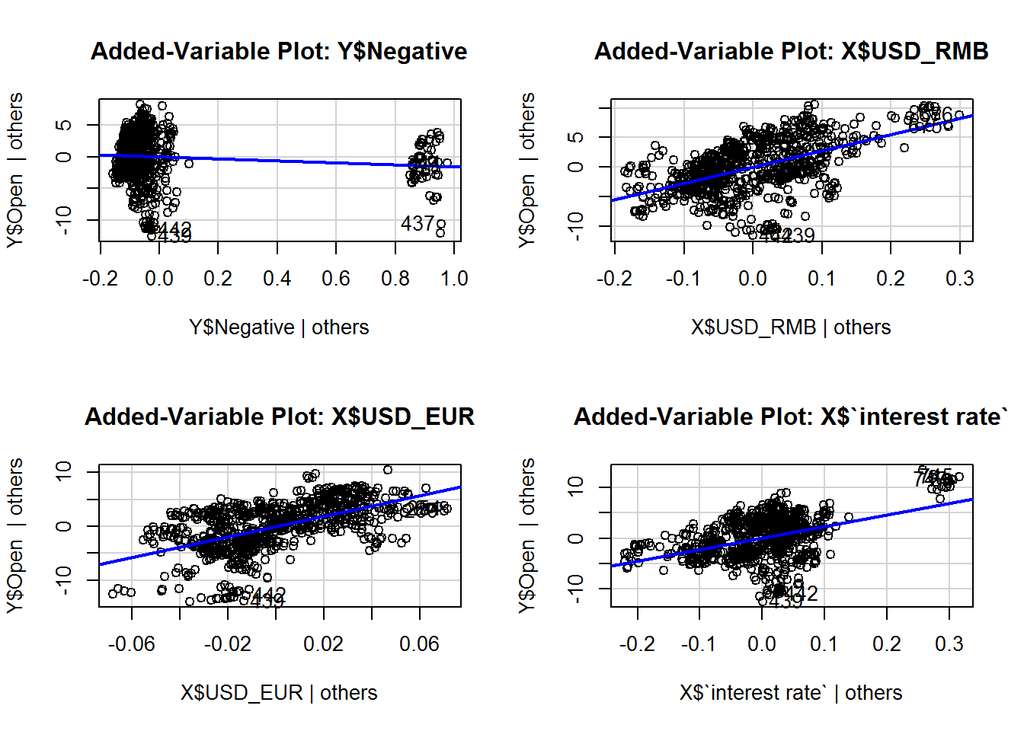

```r
avPlot(m2,variable=Y$Negative,ask=FALSE)
avPlot(m2,variable=X$USD_RMB,ask=FALSE)
avPlot(m2,variable=X$USD_EUR,ask=FALSE)
avPlot(m2,variable=X$`interest rate`,ask=FALSE)
```

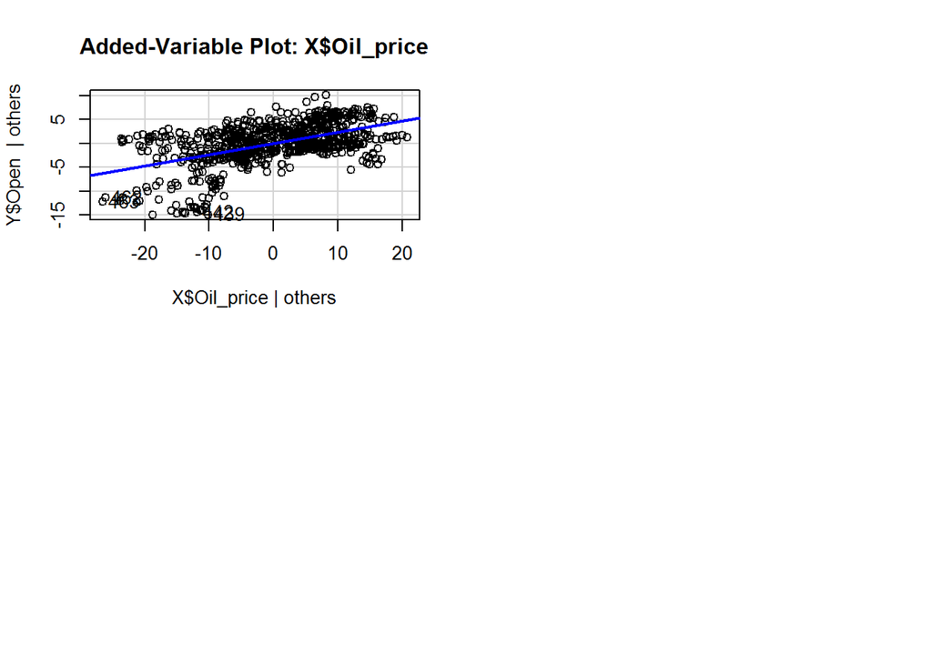

```r
avPlot(m2,variable=X$Oil_price,ask=FALSE)
```

## “Tuning” models

Randomly split the whole dataset into 70 percent for training and 30 percent for testing. Using a usual least squares linear regression model, fit to the training data:

```r
library(caTools)
set.seed(101)
sample = sample.split(Z$Date, SplitRatio = .70)
train = subset(Z, sample == TRUE)
test  = subset(Z, sample == FALSE)

attach(train)
m6=lm(Open~Positive+Negative+USD_RMB+USD_EUR+`interest rate`+Oil_price)
sm=summary(m6)
sm
```

```
##
## Call:
## lm(formula = Open ~ Positive + Negative + USD_RMB + USD_EUR +
##     `interest rate` + Oil_price)
##
## Residuals:
##      Min       1Q   Median       3Q      Max
## -11.7005  -2.1130   0.2583   2.7700   7.9772
##
## Coefficients:
##                   Estimate Std. Error t value Pr(>|t|)
## (Intercept)     -319.20024    6.64469 -48.038   <2e-16 ***
## Positive           0.13312    0.51514   0.258   0.7962
## Negative          -1.54475    0.63753  -2.423   0.0157 *
## USD_RMB           27.66160    1.61265  17.153   <2e-16 ***
## USD_EUR           94.06335    5.72683  16.425   <2e-16 ***
## `interest rate`   23.16690    2.01568  11.493   <2e-16 ***
## Oil_price          0.23280    0.01661  14.014   <2e-16 ***
## ---
## Signif. codes:  0 '***' 0.001 '**' 0.01 '*' 0.05 '.' 0.1 ' ' 1
##
## Residual standard error: 3.646 on 522 degrees of freedom
## Multiple R-squared:  0.9231, Adjusted R-squared:  0.9222
## F-statistic:  1044 on 6 and 522 DF,  p-value: < 2.2e-16
```

```r
detach(train)
```

Since MSE measures the average of the squares of the errors or deviations-that is, the difference between the estimator and what is estimated, we use MSE to identify the accuracy of our model. $MSE=\frac{1}{n} \sum_{i=1}^n (\hat{y_i}-y_i)^2$ Compute the MSE of model when applied to the training data and to the testing data:

```r
#Report the MSE of model when applied to the training data.
mse <- function(sm) {
  mean(sm$residuals^2)
}
mse(sm)
```

```
## [1] 13.11837
```

```r
#Report the MSE of your model when applied to the testing data.
y_hat <- predict(m6, test)
y=test$Open
mean((y_hat-y)^2)
```

```
## [1] 15.1159
```